# Camera Color Format Internals

Camera sensors do not directly capture RGB images.

They capture:

- Raw intensity values
- Single-channel sensor data

Color formats define:

- How color information is represented
- Number of channels
- Memory layout

Different formats are optimized for:

- Human perception
- Compression efficiency
- Hardware acceleration

# RGB Color Format

RGB represents color using Red, Green, and Blue components.

## Structure

- 3 channels per pixel: R, G, B
- Optional alpha channel: RGBA

## Properties

- Intuitive and easy to process
- High memory bandwidth usage
- No separation of brightness and color

## Used In

- Displays
- Basic image processing
- Neural network inputs

# YUV / YCbCr Color Format

YUV separates brightness from color information.

## Channels

- Y: Luminance (brightness)
- U / Cb: Blue chroma
- V / Cr: Red chroma

## Key Idea

- Human vision is more sensitive to brightness than color

## Benefits

- Enables chroma subsampling
- Efficient video compression
- Hardware-friendly camera pipelines

# YUV Subsampling Formats

Chroma channels are stored at lower resolution than luma.

## Common Formats

- YUV444: No subsampling
- YUV422: Half horizontal chroma
- YUV420: Half horizontal and vertical chroma

## Memory Layouts

- NV12: Y plane + interleaved UV
- I420: Separate Y, U, and V planes

## Benefits

- Reduced memory bandwidth
- Faster video processing
- Lower power consumption

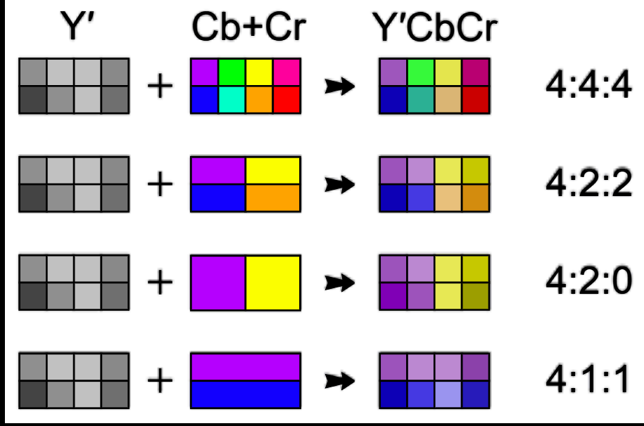

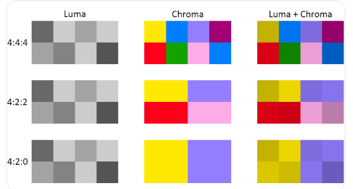

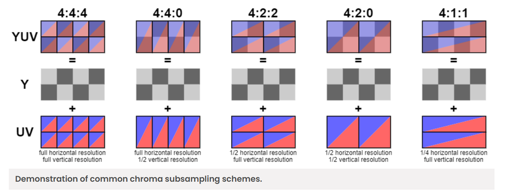

## References

- https://www.rtings.com/tv/learn/chroma-subsampling?utm_source=chatgpt.com

# LAB Color Format

LAB is a perceptual color space.

## Channels

- L: Lightness
- a: Green to Red axis
- b: Blue to Yellow axis

## Properties

- Perceptually uniform
- Large color gamut
- Non-linear conversion from RGB

## Used In

- Computer vision
- Color correction
- Image comparison and segmentation

# Bayer and Raw Sensor Formats

Image sensors capture raw Bayer-pattern data.

## Bayer Patterns

- RGGB
- BGGR
- GRBG
- GBRG

## Characteristics

- One color value per pixel
- Requires demosaicing
- Highest dynamic range

## Used In

- ISP pipelines
- Professional cameras
- Low-level vision systems

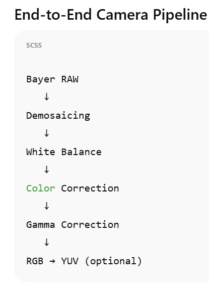